# Final Project

```
Name: Ömer Faruk YILDIRIM
Number: 070130408
```

Each student have to do a different research on his/her own. To do so you need to find and download a dataset from [World Bank](http://databank.worldbank.org/data/). Follow the instructions carefully.

- Upload your homework as HTML file: `File > Download as > HTML`
- Ask your questions from [Nivova](http://ninova.itu.edu.tr)
- You can get extra grade by showing your codes off. Extra grades can compensate your missing questions, partly. Simply, try to apply everything you have learned so far. *But do not make irrelevant coding.*
- If you late for submission of the Final project to [Nivova](http://ninova.itu.edu.tr) then you have to get a report from deanery approving your excuse.

Final project is very similar with the [Quiz 3](https://itueconomics.github.io/bil113e/assignments/pisa-scores.html). Carefully examine it.

Good luck!

## 1. Find Data and Research Question

Go to the [World Bank](http://databank.worldbank.org/data/) and find a research question. Check out the next steps and make your decision accordingly. Research questions can be:

- You can compare one country with world/region.
- You can compare two countries for something.
- You can compare all countries for something.
- You can examine the progress of something withing a country/region/world.
- You can find the relationship between two things like correlation between gdp and education.
- and so on...

You can help each other but pick up different topics. If you have the same topic and same answers then same projects will be considered as cheated.

NOTE: Download your data as CSV or Excel.

## 2. Clean Data

Make sure your data is clean. Especially check out the `tail()`. There could be some empty rows in your dataframe.

```python
import numpy as np
import pandas as pd
import matplotlib.pyplot as plt
```

```python
%matplotlib inline
```

```python
!dir
```

[output not shown]

[output cut: 19 more lines]

[output not shown]

```python
countries = pd.read_csv('nations.csv')
```

```python
countries.head()
```

|  | iso2c | iso3c | country | year | gdp_percap | life_expect | population | birth_rate | neonat_mortal_rate | region | income |
| --- | --- | --- | --- | --- | --- | --- | --- | --- | --- | --- | --- |
| 0 | AD | AND | Andorra | 1996 | NaN | NaN | 64291.0 | 10.9 | 2.8 | Europe & Central Asia | High income |
| 1 | AD | AND | Andorra | 1994 | NaN | NaN | 62707.0 | 10.9 | 3.2 | Europe & Central Asia | High income |
| 2 | AD | AND | Andorra | 2003 | NaN | NaN | 74783.0 | 10.3 | 2.0 | Europe & Central Asia | High income |
| 3 | AD | AND | Andorra | 1990 | NaN | NaN | 54511.0 | 11.9 | 4.3 | Europe & Central Asia | High income |
| 4 | AD | AND | Andorra | 2009 | NaN | NaN | 85474.0 | 9.9 | 1.7 | Europe & Central Asia | High income |

## 3. Data Manipulation

Make data manipulation:

1. Is there any null rows?
2. If there is null values what will you do?
3. Can you do some extra calculation (like Average PISA score calculation)
4. Clean unnecessary columns.
5. and more...

Show your code, do not make any comment.

```python
countries['gdp_percap'].fillna(countries['gdp_percap'].median(),inplace=True)
countries.head() #Your code here
```

|  | iso2c | iso3c | country | year | gdp_percap | life_expect | population | birth_rate | neonat_mortal_rate | region | income |
| --- | --- | --- | --- | --- | --- | --- | --- | --- | --- | --- | --- |
| 0 | AD | AND | Andorra | 1996 | 6563.171063 | NaN | 64291.0 | 10.9 | 2.8 | Europe & Central Asia | High income |
| 1 | AD | AND | Andorra | 1994 | 6563.171063 | NaN | 62707.0 | 10.9 | 3.2 | Europe & Central Asia | High income |
| 2 | AD | AND | Andorra | 2003 | 6563.171063 | NaN | 74783.0 | 10.3 | 2.0 | Europe & Central Asia | High income |
| 3 | AD | AND | Andorra | 1990 | 6563.171063 | NaN | 54511.0 | 11.9 | 4.3 | Europe & Central Asia | High income |
| 4 | AD | AND | Andorra | 2009 | 6563.171063 | NaN | 85474.0 | 9.9 | 1.7 | Europe & Central Asia | High income |

```python
countries.groupby(['country']).mean()
```

| country | year | gdp_percap | life_expect | population | birth_rate | neonat_mortal_rate |
| --- | --- | --- | --- | --- | --- | --- |
| Afghanistan | 2002 | 3875.455615 | 55.730645 | 2.179472e+07 | 44.828320 | 43.896 |
| Albania | 2002 | 5641.509114 | 74.782879 | 3.064024e+06 | 16.351120 | 10.300 |
| Algeria | 2002 | 9608.372262 | 70.871015 | 3.215538e+07 | 23.690920 | 19.592 |
| American Samoa | 2002 | 6563.171063 | NaN | 5.522432e+04 | 20.150000 | NaN |
| Andorra | 2002 | 6563.171063 | NaN | 7.147152e+04 | 11.013636 | 2.364 |
| Angola | 2002 | 4115.678146 | 46.411900 | 1.674582e+07 | 49.994320 | 56.400 |
| Antigua and Barbuda | 2002 | 16961.378101 | 73.723386 | 7.787732e+04 | 18.687600 | 9.064 |
| Argentina | 2002 | 6563.171063 | 74.013997 | 3.788757e+07 | 19.386320 | 10.564 |
| Armenia | 2002 | 3992.636430 | 71.608266 | 3.120281e+06 | 14.994960 | 14.864 |
| Aruba | 2002 | 7741.247039 | 74.139799 | 9.044324e+04 | 13.917160 | NaN |
| Australia | 2002 | 29909.325163 | 79.801639 | 1.986744e+07 | 13.640000 | 3.376 |
| Austria | 2002 | 32440.578064 | 78.568683 | 8.122065e+06 | 10.180000 | 3.108 |
| Azerbaijan | 2002 | 7916.242744 | 67.543019 | 8.264071e+06 | 18.232000 | 29.668 |
| Bahamas, The | 2002 | 20030.669610 | 72.857976 | 3.154073e+05 | 18.223400 | 9.408 |
| Bahrain | 2002 | 35876.449331 | 74.792564 | 8.411788e+05 | 20.641680 | 5.468 |
| Bangladesh | 2002 | 1655.148382 | 65.846570 | 1.345002e+08 | 26.578840 | 41.092 |
| Barbados | 2002 | 12123.359699 | 73.474844 | 2.716654e+05 | 13.718160 | 9.368 |
| Belarus | 2002 | 9118.246224 | 69.660137 | 9.848120e+06 | 10.652000 | 6.000 |
| Belgium | 2002 | 30545.334583 | 78.361541 | 1.045734e+07 | 11.564000 | 3.060 |
| Belize | 2002 | 6051.899126 | 69.520085 | 2.627800e+05 | 28.633280 | 12.552 |
| Benin | 2002 | 1409.111949 | 56.377472 | 7.587077e+06 | 41.549360 | 38.232 |
| Bermuda | 2002 | 40909.171044 | 78.958043 | 6.244744e+04 | 12.940909 | NaN |
| Bhutan | 2002 | 3903.189133 | 61.888694 | 6.145962e+05 | 26.543480 | 30.980 |
| Bolivia | 2002 | 4035.449794 | 61.825289 | 8.668422e+06 | 29.688240 | 29.836 |
| Bosnia and Herzegovina | 2002 | 6171.868874 | 73.929645 | 3.912003e+06 | 10.563000 | 6.952 |
| Botswana | 2002 | 9595.707798 | 57.203290 | 1.791370e+06 | 27.852720 | 24.572 |
| Brazil | 2002 | 10460.294858 | 70.373750 | 1.798673e+08 | 19.341280 | 15.216 |
| Brunei Darussalam | 2002 | 63116.905041 | 75.757040 | 3.409642e+05 | 22.186760 | 5.048 |
| Bulgaria | 2002 | 9508.331327 | 72.337005 | 7.939155e+06 | 9.448000 | 9.748 |
| Burkina Faso | 2002 | 994.190800 | 52.670543 | 1.263315e+07 | 44.929640 | 38.484 |
| ... | ... | ... | ... | ... | ... | ... |
| Sweden | 2002 | 31880.802752 | 79.959434 | 9.025230e+06 | 11.756000 | 2.240 |
| Switzerland | 2002 | 39359.370111 | 80.318283 | 7.363267e+06 | 10.800000 | 3.344 |
| Syrian Arab Republic | 2002 | 6563.171063 | 72.204137 | 1.691943e+07 | 29.223560 | 11.624 |
| Tajikistan | 2002 | 1572.631792 | 65.240582 | 6.581095e+06 | 32.277280 | 27.776 |
| Tanzania | 2002 | 1497.448429 | 54.447210 | 3.698677e+07 | 41.909960 | 29.408 |
| Thailand | 2002 | 9328.267433 | 71.725658 | 6.316971e+07 | 14.281200 | 12.264 |
| Timor-Leste | 2002 | 3547.868272 | 60.241549 | 9.404988e+05 | 41.833800 | 36.304 |
| Togo | 2002 | 1054.458493 | 55.479003 | 5.257264e+06 | 39.312400 | 34.860 |
| Tonga | 2002 | 3889.531339 | 71.085665 | 9.959116e+04 | 28.418080 | 7.824 |
| Trinidad and Tobago | 2002 | 19023.693909 | 68.957641 | 1.285268e+06 | 15.785240 | 17.532 |
| Tunisia | 2002 | 7157.692986 | 72.757171 | 9.685100e+06 | 19.308000 | 17.156 |
| Turkey | 2002 | 10560.202345 | 70.470241 | 6.514931e+07 | 20.947360 | 18.564 |
| Turkmenistan | 2002 | 6566.927197 | 64.044855 | 4.568699e+06 | 25.248120 | 28.800 |
| Turks and Caicos Islands | 2002 | 6563.171063 | NaN | 2.246452e+04 | NaN | NaN |
| Tuvalu | 2002 | 2607.274008 | NaN | 9.509520e+03 | NaN | 24.636 |
| Uganda | 2002 | 1044.778438 | 49.607680 | 2.622638e+07 | 47.366760 | 29.320 |
| Ukraine | 2002 | 5956.037477 | 68.752029 | 4.860748e+07 | 9.934031 | 9.828 |
| United Arab Emirates | 2002 | 74738.442986 | 74.805308 | 4.592657e+06 | 16.300960 | 5.568 |
| United Kingdom | 2002 | 29317.161363 | 78.406878 | 6.006595e+07 | 12.488000 | 3.604 |
| United States | 2002 | 38817.320943 | 77.068488 | 2.863821e+08 | 14.188000 | 4.608 |
| Uruguay | 2002 | 11832.697445 | 74.928367 | 3.297683e+06 | 16.191640 | 8.268 |
| Uzbekistan | 2002 | 2758.923890 | 67.146821 | 2.539436e+07 | 24.660543 | 27.092 |
| Vanuatu | 2002 | 2302.657602 | 68.009801 | 1.984141e+05 | 31.256640 | 12.840 |
| Venezuela, RB | 2002 | 12777.949708 | 72.359536 | 2.536385e+07 | 23.491800 | 11.392 |
| Vietnam | 2002 | 2795.631568 | 73.349880 | 7.906156e+07 | 19.738840 | 16.160 |
| Virgin Islands (U.S.) | 2002 | 6563.171063 | 77.669382 | 1.069622e+05 | 15.346800 | NaN |
| West Bank and Gaza | 2002 | 3993.824644 | 70.838780 | 3.095605e+06 | 39.032080 | 16.280 |
| Yemen, Rep. | 2002 | 3374.812254 | 60.859683 | 1.900743e+07 | 40.061400 | 34.316 |
| Zambia | 2002 | 2193.173278 | 48.324932 | 1.141186e+07 | 43.665360 | 30.448 |
| Zimbabwe | 2002 | 1678.366272 | 48.317740 | 1.272901e+07 | 34.754120 | 22.444 |

211 rows × 6 columns

```python
average_gdp_percap = countries.groupby(['country']).mean()['gdp_percap']
```

```python
average_gdp_percap
```

```
country
Afghanistan                  3875.455615
Albania                      5641.509114
Algeria                      9608.372262
American Samoa               6563.171063
Andorra                      6563.171063
Angola                       4115.678146
Antigua and Barbuda         16961.378101
Argentina                    6563.171063
Armenia                      3992.636430
Aruba                        7741.247039
Australia                   29909.325163
Austria                     32440.578064
Azerbaijan                   7916.242744
Bahamas, The                20030.669610
Bahrain                     35876.449331
Bangladesh                   1655.148382
Barbados                    12123.359699
Belarus                      9118.246224
Belgium                     30545.334583
Belize                       6051.899126
Benin                        1409.111949
Bermuda                     40909.171044
Bhutan                       3903.189133
Bolivia                      4035.449794
Bosnia and Herzegovina       6171.868874
Botswana                     9595.707798
Brazil                      10460.294858
Brunei Darussalam           63116.905041
Bulgaria                     9508.331327
Burkina Faso                  994.190800
                                ...
Sweden                      31880.802752
Switzerland                 39359.370111
Syrian Arab Republic         6563.171063
Tajikistan                   1572.631792
Tanzania                     1497.448429
Thailand                     9328.267433
Timor-Leste                  3547.868272
Togo                         1054.458493
```

[output cut: 8 more lines]

```
Ukraine                      5956.037477
United Arab Emirates        74738.442986
United Kingdom              29317.161363
United States               38817.320943
Uruguay                     11832.697445
Uzbekistan                   2758.923890
Vanuatu                      2302.657602
Venezuela, RB               12777.949708
Vietnam                      2795.631568
Virgin Islands (U.S.)        6563.171063
West Bank and Gaza           3993.824644
Yemen, Rep.                  3374.812254
Zambia                       2193.173278
Zimbabwe                     1678.366272
Name: gdp_percap, Length: 211, dtype: float64
```

```python
topeight = avg_gdp_percap.sort_values(ascending=False).head(8)
topeight
```

```
country
United Arab Emirates    74738.442986
Qatar                   70772.168796
Brunei Darussalam       63116.905041
Luxembourg              62343.738409
Kuwait                  58301.181985
Macao SAR, China        58266.189888
Singapore               48715.814306
Norway                  41280.588510
Name: gdp_percap, dtype: float64
```

```python
china = countries[countries['country'] == 'Macao SAR, China']
china
```

|  | iso2c | iso3c | country | year | gdp_percap | life_expect | population | birth_rate | neonat_mortal_rate | region | income |
| --- | --- | --- | --- | --- | --- | --- | --- | --- | --- | --- | --- |
| 3175 | MO | MAC | Macao SAR, China | 1997 | 29984.138229 | 76.962756 | 412031.0 | 11.470 | NaN | East Asia & Pacific | High income |
| 3176 | MO | MAC | Macao SAR, China | 2005 | 58922.097492 | 78.649024 | 468149.0 | 7.806 | NaN | East Asia & Pacific | High income |
| 3177 | MO | MAC | Macao SAR, China | 2003 | 42126.842348 | 78.246293 | 450754.0 | 7.757 | NaN | East Asia & Pacific | High income |
| 3178 | MO | MAC | Macao SAR, China | 2013 | 141968.100275 | 80.339146 | 568056.0 | 11.256 | NaN | East Asia & Pacific | High income |
| 3179 | MO | MAC | Macao SAR, China | 2008 | 78666.565905 | 79.264610 | 507274.0 | 8.999 | NaN | East Asia & Pacific | High income |
| 3180 | MO | MAC | Macao SAR, China | 2010 | 96619.844399 | 79.690390 | 534626.0 | 10.032 | NaN | East Asia & Pacific | High income |
| 3181 | MO | MAC | Macao SAR, China | 2012 | 127938.918712 | 80.123171 | 557763.0 | 10.913 | NaN | East Asia & Pacific | High income |
| 3182 | MO | MAC | Macao SAR, China | 1996 | 30064.471198 | 76.734415 | 405231.0 | 12.345 | NaN | East Asia & Pacific | High income |
| 3183 | MO | MAC | Macao SAR, China | 1994 | 29075.647323 | 76.265244 | 391783.0 | 14.294 | NaN | East Asia & Pacific | High income |
| 3184 | MO | MAC | Macao SAR, China | 1999 | 27749.601396 | 77.406976 | 425448.0 | 9.804 | NaN | East Asia & Pacific | High income |
| 3185 | MO | MAC | Macao SAR, China | 2000 | 29550.149020 | 77.622829 | 431907.0 | 9.069 | NaN | East Asia & Pacific | High income |
| 3186 | MO | MAC | Macao SAR, China | 2001 | 34407.773259 | 77.834659 | 438088.0 | 8.460 | NaN | East Asia & Pacific | High income |
| 3187 | MO | MAC | Macao SAR, China | 2014 | 140630.079451 | 80.553098 | 577914.0 | 11.514 | NaN | East Asia & Pacific | High income |
| 3188 | MO | MAC | Macao SAR, China | 2006 | 67157.307919 | 78.851561 | 479728.0 | 8.096 | NaN | East Asia & Pacific | High income |
| 3189 | MO | MAC | Macao SAR, China | 2007 | 76777.764017 | 79.056244 | 493022.0 | 8.511 | NaN | East Asia & Pacific | High income |
| 3190 | MO | MAC | Macao SAR, China | 1991 | 23190.130338 | 75.530780 | 369484.0 | 17.999 | NaN | East Asia & Pacific | High income |
| 3191 | MO | MAC | Macao SAR, China | 2004 | 53929.953004 | 78.448122 | 458579.0 | 7.688 | NaN | East Asia & Pacific | High income |
| 3192 | MO | MAC | Macao SAR, China | 2009 | 78134.582879 | 79.476171 | 521405.0 | 9.520 | NaN | East Asia & Pacific | High income |
| 3193 | MO | MAC | Macao SAR, China | 1993 | 27773.991797 | 76.024415 | 385041.0 | 15.441 | NaN | East Asia & Pacific | High income |
| 3194 | MO | MAC | Macao SAR, China | 2011 | 117340.970751 | 79.906244 | 546682.0 | 10.501 | NaN | East Asia & Pacific | High income |
| 3195 | MO | MAC | Macao SAR, China | 1995 | 30147.858785 | 76.502073 | 398459.0 | 13.269 | NaN | East Asia & Pacific | High income |
| 3196 | MO | MAC | Macao SAR, China | 1998 | 28447.271131 | 77.186610 | 418810.0 | 10.617 | NaN | East Asia & Pacific | High income |
| 3197 | MO | MAC | Macao SAR, China | 1992 | 26281.899061 | 75.779610 | 377799.0 | 16.695 | NaN | East Asia & Pacific | High income |
| 3198 | MO | MAC | Macao SAR, China | 1990 | 22228.860282 | 75.276976 | 359735.0 | 19.272 | NaN | East Asia & Pacific | High income |
| 3199 | MO | MAC | Macao SAR, China | 2002 | 37539.928235 | 78.041976 | 444178.0 | 8.016 | NaN | East Asia & Pacific | High income |

## 4. Data Visualization

Do data visualization properly. It should show something meaningful.

```python
china = china.sort_values(by=['year'])# Your code here
```

```
Text(0,0.5,'GDP')
```

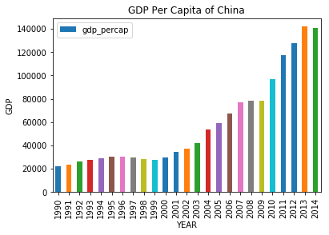

```python
china.plot.bar(x = 'year', y = 'gdp_percap')
plt.title('GDP Per Capita of China')
plt.xlabel('YEAR')
plt.ylabel('GDP')
#china['gdp_percap'].sort_values().plot('bar')
```

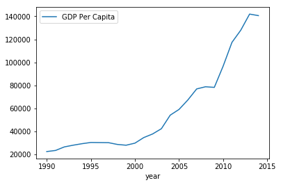

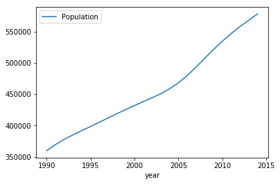

```python
fig = plt.figure(figsize=(8,10), dpi = 80)
china.plot('year','gdp_percap',label="GDP Per Capita")
china.plot('year','population', label="Population")
```

```python
countries.describe()
```

|  | year | gdp_percap | life_expect | population | birth_rate | neonat_mortal_rate |
| --- | --- | --- | --- | --- | --- | --- |
| count | 5275.000000 | 5275.000000 | 4882.000000 | 5.261000e+03 | 4980.000000 | 4750.000000 |
| mean | 2002.000000 | 11884.747078 | 67.775188 | 2.958181e+07 | 24.155666 | 19.397853 |
| std | 7.211786 | 15228.165904 | 9.953131 | 1.192347e+08 | 11.861722 | 15.103225 |
| min | 1990.000000 | 239.739376 | 27.078902 | 9.004000e+03 | 6.900000 | 0.700000 |
| 25% | 1996.000000 | 2744.253153 | 61.243738 | 7.175020e+05 | 13.400000 | 6.700000 |
| 50% | 2002.000000 | 6563.171063 | 70.457854 | 5.303294e+06 | 21.600000 | 15.000000 |
| 75% | 2008.000000 | 14531.842172 | 75.170951 | 1.756858e+07 | 33.883500 | 29.475000 |
| max | 2014.000000 | 141968.100275 | 83.980488 | 1.364270e+09 | 55.122000 | 73.100000 |

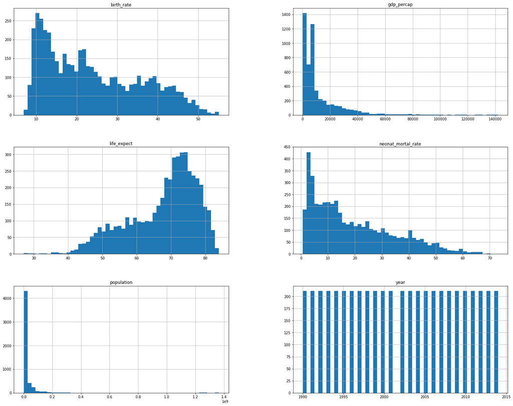

```python
countries.hist(bins=50, figsize=(25,20))
plt.savefig('numeric.png')
plt.show()
```

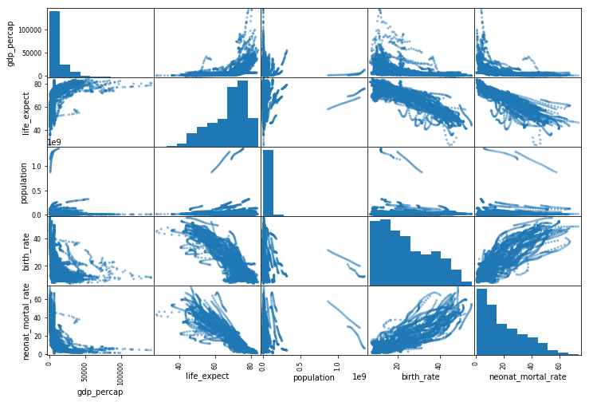

```python
from pandas.plotting import scatter_matrix

attributes = ["gdp_percap", "life_expect", "population", "birth_rate", "neonat_mortal_rate"]
scatter_matrix(countries[attributes], figsize=(12, 8))
plt.savefig("scatter_matrix_plot.png")
plt.show()
```

NOTE: If you use extra attributes for data visualization you will get extra grade. Like adding grid, title, changing colors etc.

## 5. Statistical analysis

You can:

- Investigate the correlation between two or more variables/Series
- Show the trends/seasonality of the series
- Apply linear models as in [sklearn](https://itueconomics.github.io/bil113e/titanic.html) lecture.
- Make forecasts
- and so on...

```python
#to run the regression without problems; I will delete columns that contain strings
#data cleaning;
del china['iso2c']
del china['iso3c']
del china['neonat_mortal_rate']
del china['region']
del china['income']
china.head(55)# Your code here
```

|  | country | year | gdp_percap | life_expect | population | birth_rate |
| --- | --- | --- | --- | --- | --- | --- |
| 3198 | Macao SAR, China | 1990 | 22228.860282 | 75.276976 | 359735.0 | 19.272 |
| 3190 | Macao SAR, China | 1991 | 23190.130338 | 75.530780 | 369484.0 | 17.999 |
| 3197 | Macao SAR, China | 1992 | 26281.899061 | 75.779610 | 377799.0 | 16.695 |
| 3193 | Macao SAR, China | 1993 | 27773.991797 | 76.024415 | 385041.0 | 15.441 |
| 3183 | Macao SAR, China | 1994 | 29075.647323 | 76.265244 | 391783.0 | 14.294 |
| 3195 | Macao SAR, China | 1995 | 30147.858785 | 76.502073 | 398459.0 | 13.269 |
| 3182 | Macao SAR, China | 1996 | 30064.471198 | 76.734415 | 405231.0 | 12.345 |
| 3175 | Macao SAR, China | 1997 | 29984.138229 | 76.962756 | 412031.0 | 11.470 |
| 3196 | Macao SAR, China | 1998 | 28447.271131 | 77.186610 | 418810.0 | 10.617 |
| 3184 | Macao SAR, China | 1999 | 27749.601396 | 77.406976 | 425448.0 | 9.804 |
| 3185 | Macao SAR, China | 2000 | 29550.149020 | 77.622829 | 431907.0 | 9.069 |
| 3186 | Macao SAR, China | 2001 | 34407.773259 | 77.834659 | 438088.0 | 8.460 |
| 3199 | Macao SAR, China | 2002 | 37539.928235 | 78.041976 | 444178.0 | 8.016 |
| 3177 | Macao SAR, China | 2003 | 42126.842348 | 78.246293 | 450754.0 | 7.757 |
| 3191 | Macao SAR, China | 2004 | 53929.953004 | 78.448122 | 458579.0 | 7.688 |
| 3176 | Macao SAR, China | 2005 | 58922.097492 | 78.649024 | 468149.0 | 7.806 |
| 3188 | Macao SAR, China | 2006 | 67157.307919 | 78.851561 | 479728.0 | 8.096 |
| 3189 | Macao SAR, China | 2007 | 76777.764017 | 79.056244 | 493022.0 | 8.511 |
| 3179 | Macao SAR, China | 2008 | 78666.565905 | 79.264610 | 507274.0 | 8.999 |
| 3192 | Macao SAR, China | 2009 | 78134.582879 | 79.476171 | 521405.0 | 9.520 |
| 3180 | Macao SAR, China | 2010 | 96619.844399 | 79.690390 | 534626.0 | 10.032 |
| 3194 | Macao SAR, China | 2011 | 117340.970751 | 79.906244 | 546682.0 | 10.501 |
| 3181 | Macao SAR, China | 2012 | 127938.918712 | 80.123171 | 557763.0 | 10.913 |
| 3178 | Macao SAR, China | 2013 | 141968.100275 | 80.339146 | 568056.0 | 11.256 |
| 3187 | Macao SAR, China | 2014 | 140630.079451 | 80.553098 | 577914.0 | 11.514 |

```python
from sklearn.linear_model import LinearRegression
```

```python
X = china.drop(['country', 'birth_rate'], axis=1)
regressor = LinearRegression()
regressor.fit(X, china.birth_rate)
print('Estimated int. coef', regressor)
```

```
Estimated int. coef LinearRegression(copy_X=True, fit_intercept=True, n_jobs=1, normalize=False)
```

```python
print('Estimated intercept coefficient:', regressor.intercept_)
print('Numbers of coefficients:', len(regressor.coef_))
pd.DataFrame(list(zip(X.columns, regressor.coef_)), columns = ['Features', 'est_coef'])
```

```
Estimated intercept coefficient: -3802.724202942814
Numbers of coefficients: 4
```

|  | Features | est_coef |
| --- | --- | --- |
| 0 | year | 2.627107 |
| 1 | gdp_percap | 0.000036 |
| 2 | life_expect | -19.268395 |
| 3 | population | 0.000121 |

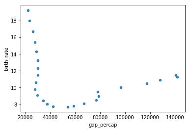

```python
china.plot(kind="scatter", x="gdp_percap", y="birth_rate", alpha=0.9)
```

```python
from sklearn.model_selection import train_test_split
import sklearn

y = china.birth_rate
X_train, X_test, y_train, y_test = train_test_split(X, y, test_size=0.2, random_state=0)
```

```python
from sklearn.linear_model import LinearRegression
regressor = LinearRegression()
regressor.fit(X_train, y_train)
```

```
LinearRegression(copy_X=True, fit_intercept=True, n_jobs=1, normalize=False)
```

```python
y_pred = regressor.predict(X_test)

regressor.score(X_test, y_test)
```

```
0.997733751104647
```

```
Text(0,0.5,'Residual')
```

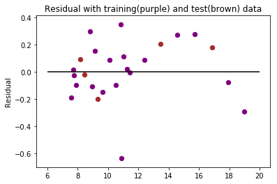

```python
plt.scatter(regressor.predict(X_train), regressor.predict(X_train)-y_train, c='purple', s=40)
plt.scatter(regressor.predict(X_test), regressor.predict(X_test)-y_test, c='brown', s=40)
plt.hlines(y=0, xmin=6, xmax=20)
plt.title('Residual with training(purple) and test(brown) data')
plt.ylabel('Residual')
```